# lab6_Khan

[Хань Євгеній](https://github.com/amx122), 2024

## Завдання для самостійної роботи

```
Точність класифікації методом k найближчих сусідів: 0.70
Таблиця частот точності класифікації:
--------------------------------------------------
| Клас | Правильно класифіковано | Неправильно класифіковано |
--------------------------------------------------
|  -1  |             4             |              1               |
|  1  |             3             |              2               |
--------------------------------------------------
```

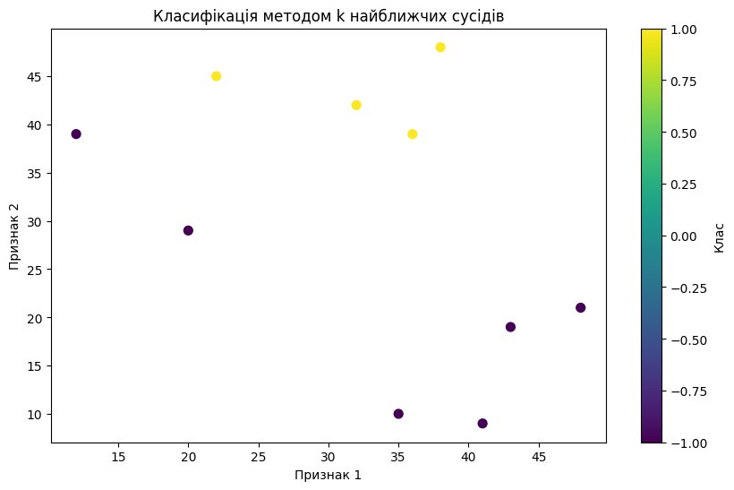

```python
import numpy as np
import matplotlib.pyplot as plt
from sklearn.neighbors import KNeighborsClassifier
from sklearn.metrics import accuracy_score

# Ваші дані
x_train_6 = np.array([[49, 21], [5, 5], [37, 32], [21, 25], [34, 28], [44, 35], [39, 41], [17, 45], [31, 24]])
y_train_6 = np.array([-1, 1, 1, -1, -1, -1, 1, -1, 1])

# Тестовий набір даних
x_test_6 = np.array([[35, 10], [36, 39], [41, 9], [43, 19], [32, 42], [38, 48], [12, 39], [22, 45], [20, 29], [48, 21]])
y_test_6 = np.array([-1, -1, -1, 1, 1, 1, -1, 1, -1, 1])

# Визначення класифікатора та навчання моделі
k = 3  # Кількість найближчих сусідів
knn = KNeighborsClassifier(n_neighbors=k)
knn.fit(x_train_6, y_train_6)

# Прогнозування класів для тестових даних
y_pred_6 = knn.predict(x_test_6)

# Оцінка точності класифікації
accuracy_6 = accuracy_score(y_test_6, y_pred_6)
print(f"Точність класифікації методом k найближчих сусідів: {accuracy_6:.2f}")

# Вивід таблиці частот точності класифікації
print("Таблиця частот точності класифікації:")
print("--------------------------------------------------")
print("| Клас | Правильно класифіковано | Неправильно класифіковано |")
print("--------------------------------------------------")
for target in np.unique(y_test_6):
    correct = np.sum((y_test_6 == target) & (y_pred_6 == target))
    incorrect = np.sum((y_test_6 == target) & (y_pred_6 != target))
    print(f"|  {target}  | {correct:^25} | {incorrect:^28} |")
print("--------------------------------------------------")

# Візуалізація
plt.figure(figsize=(10, 6))
plt.scatter(x_test_6[:, 0], x_test_6[:, 1], c=y_pred_6, cmap='viridis', s=50)
plt.title('Класифікація методом k найближчих сусідів')
plt.xlabel('Признак 1')
plt.ylabel('Признак 2')
plt.colorbar(label='Клас')
plt.show()
```

# Контрольні запитання

1. **Ідея методу головних компонент (PCA):**
   - PCA - це статистичний метод, який використовується для зменшення розмірності даних шляхом проектування їх на простір меншої розмірності зберігаючи при цьому якнайбільше можливу дисперсію.
2. **Використання PCA для зменшення розмірності даних:**
   - PCA обчислює нові нелінійні функції змінних (головні компоненти), які є лінійними комбінаціями вихідних змінних. Змінні зберігаються в порядку від максимальної до мінімальної дисперсії. Після цього можна відкинути менш важливі головні компоненти, зменшуючи таким чином розмірність даних.
3. **Пов'язаність PCA та SVD:**
   - PCA можна виконати за допомогою методу SVD (розкладу з використанням сингулярних значень). Він полягає в розкладі матриці даних на добуток трьох матриць, що дозволяє отримати головні компоненти.
4. **Метрики якості в багатокласовій класифікації:**
   - Для оцінки класифікатора використовуються такі метрики як точність, відновлення, F1-міра, матриця плутанини тощо.
5. **Відмінності стратегій one-vs-all та all-vs-all у багатокласовій класифікації:**
   - В стратегії one-vs-all для кожного класу тренується класифікатор, який відрізняє цей клас від всіх інших. У стратегії all-vs-all тренується класифікатор для кожної пари класів.
6. **Гіпотеза компактності в метричних методах класифікації:**
   - Гіпотеза компактності стверджує, що схожі об'єкти мають схожі класи.
7. **Метод k-найближчих сусідів (kNN):**
   - kNN класифікує нові об'єкти, порівнюючи їх з k найближчими об'єктами з навчального набору. Він має високу точність на навчальних даних, але може виявитися неефективним на великих об'ємах даних.
8. **Суть методу парзенівського вікна:**
   - Метод парзенівського вікна використовує ваговану суму класів навколо тестового об'єкта для прийняття рішення про класифікацію. Розмір вікна визначається вручну або автоматично.
9. **Суть методу потенційних функцій у метричних методах класифікації:**
   - Метод потенційних функцій використовує функцію відстані для призначення ваг класам. Об'єктам з низькою відстанню до точок навчання надається більше ваги при класифікації.